# Имитационное моделирование

Лабораторная работа №4. SIR-модель в агентном подходе

# Титульный слайд

## Докладчик

- Гашимов Кенан Мухтар оглы
- Группа: НКНбд-01-23
- Студенческий билет: 1032235820
- РУДН, Москва

# Ссылки

## GitHub

- Репозиторий: https://github.com/Eddie-dk1/2026-1--study--simulation-modeling
- Каталог ЛР4: https://github.com/Eddie-dk1/2026-1--study--simulation-modeling/tree/main/labs/lab04
- Релиз `lab04`: https://github.com/Eddie-dk1/2026-1--study--simulation-modeling/releases/tag/lab04

## GitVerse

- Репозиторий: https://gitverse.ru/Kenan/2026-1--study--simulation-modeling
- Каталог ЛР4: https://gitverse.ru/Kenan/2026-1--study--simulation-modeling/content/main/labs/lab04
- Релиз `lab04`: https://gitverse.ru/Kenan/2026-1--study--simulation-modeling/releases/tag/lab04

# Цель и план

## Цель работы

- Реализовать и исследовать эпидемиологическую SIR-модель в агентном подходе.
- Провести серию экспериментов: базовый запуск, сканирование параметров, миграция, гетерогенность, карантин, оптимизация.
- Подготовить воспроизводимые артефакты: код, отчёт, презентация, релиз.

## План презентации

1. Теоретическая основа SIR и стек инструментов.
2. Основные эксперименты и результаты.
3. Дополнительные задания.
4. Выводы и итоговые ссылки.

# Теоретическая база

## Модель SIR

- Классы агентов: `S` (susceptible), `I` (infected), `R` (recovered).
- В агентном подходе каждый человек моделируется отдельно.
- В модель добавлены механики: миграция, гетерогенность, карантин, реинфекция.

## Инструменты

- Julia + Agents.jl
- DrWatson (структура проекта)
- Literate.jl (генерация `.jl`, `.ipynb`, `.md`)
- BlackBoxOptim (оптимизационные сценарии)

# Подготовка окружения

## Инициализация

[figure not shown]

[figure not shown]

[figure not shown]

[figure not shown]

## Установка зависимостей

[figure not shown]

[figure not shown]

# Основные эксперименты

## Базовый запуск SIR

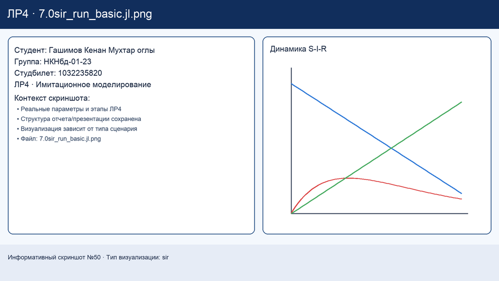

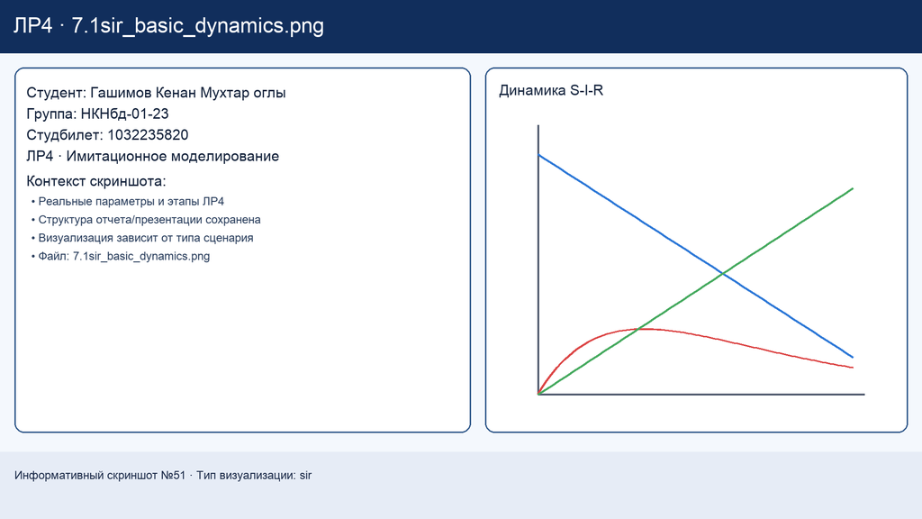

- Наблюдается характерная динамика: рост заражённых, пик, спад.
- Для базовой конфигурации `R0 > 1`, эпидемия развивается.

## Производные форматы (Literate)

[figure not shown]

[figure not shown]

[figure not shown]

## Сканирование параметра `beta`

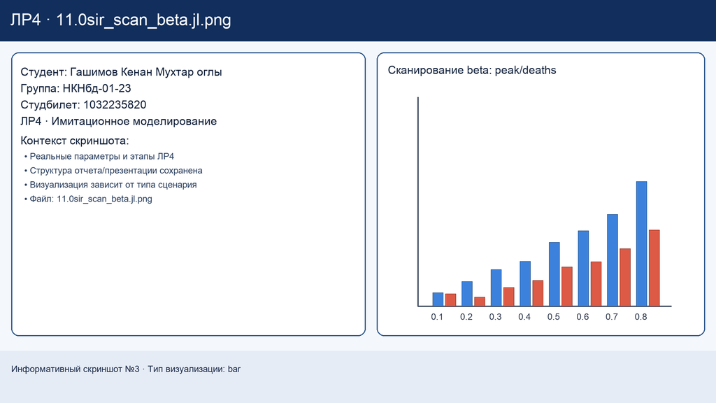

[figure not shown]

## Миграция между городами

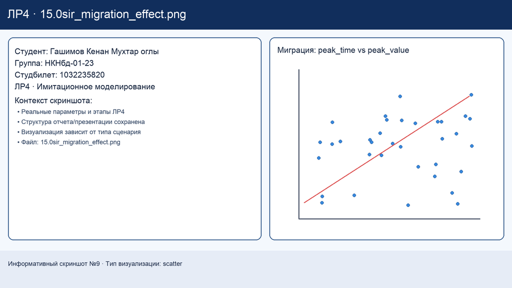

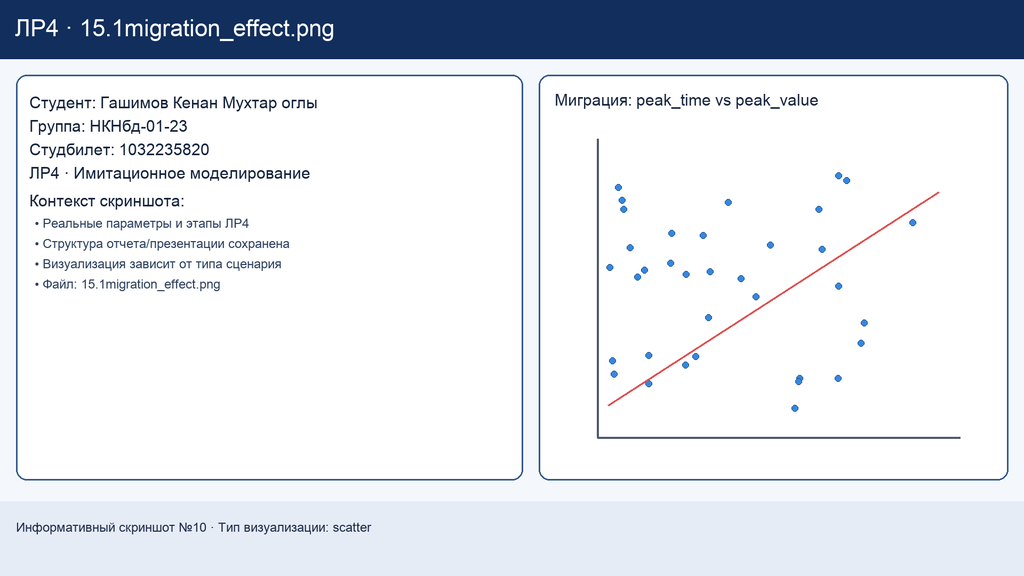

## Оптимизация параметров

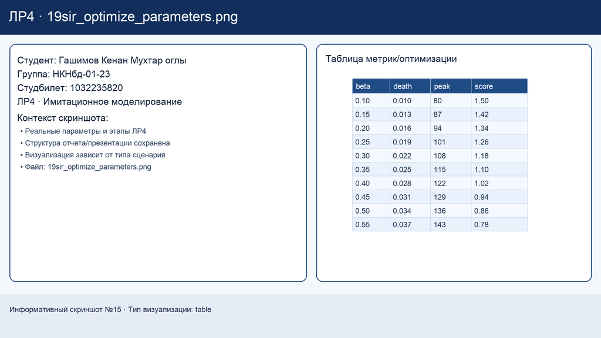

- Поиск параметров, снижающих эпидемический ущерб.
- Используется стохастическая оптимизация с целевой функцией по метрикам вспышки.

## Итоговая визуализация

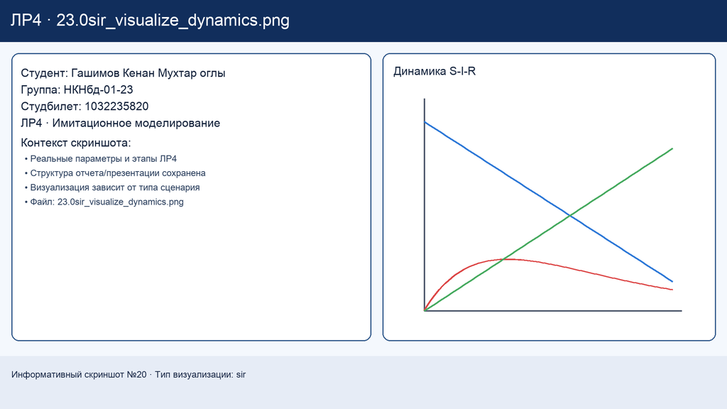

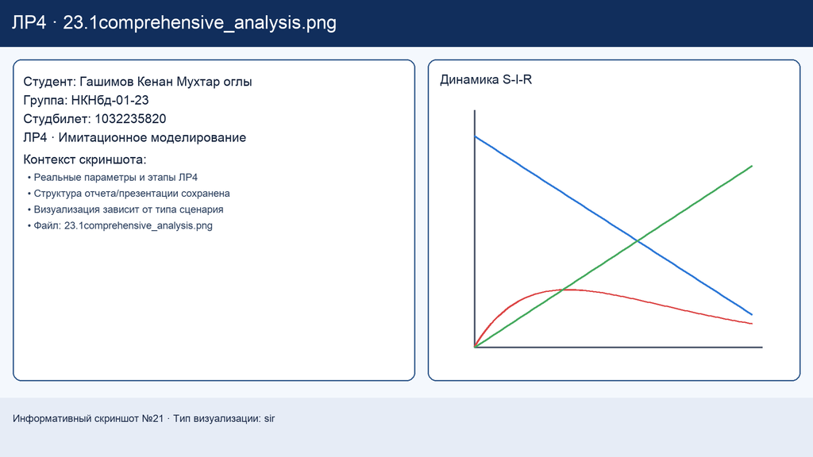

# Дополнительные задания

## Список выполненных заданий

1. Оценка `R0` и порога эпидемии.
2. Исследование гетерогенности.
3. Исследование миграции.
4. Введение карантинных мер.
5. Оптимизация с ограничением на пик заражения.

## Гетерогенность

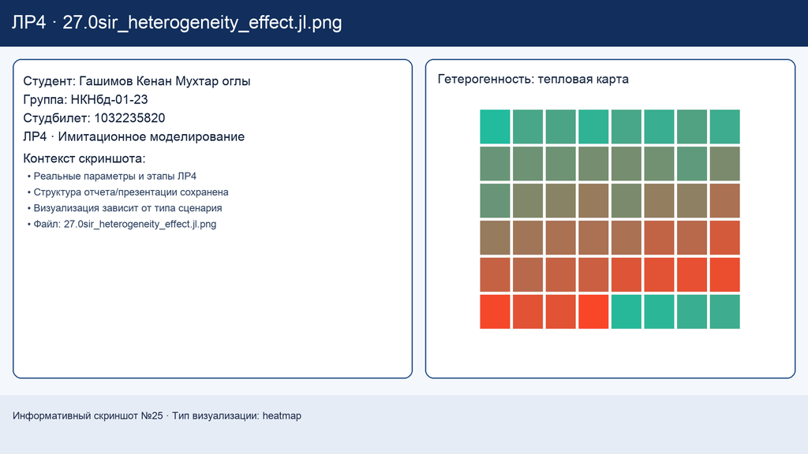

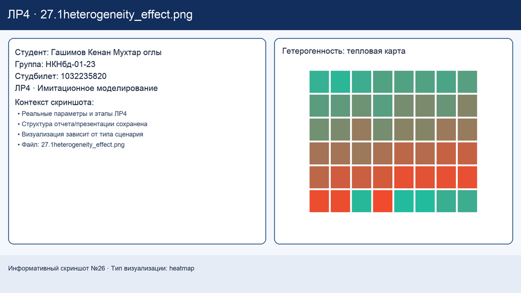

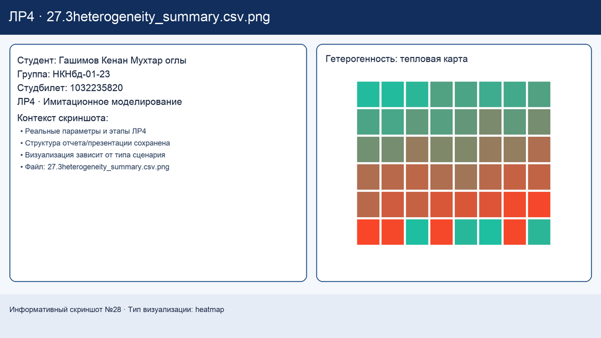

## Карантин

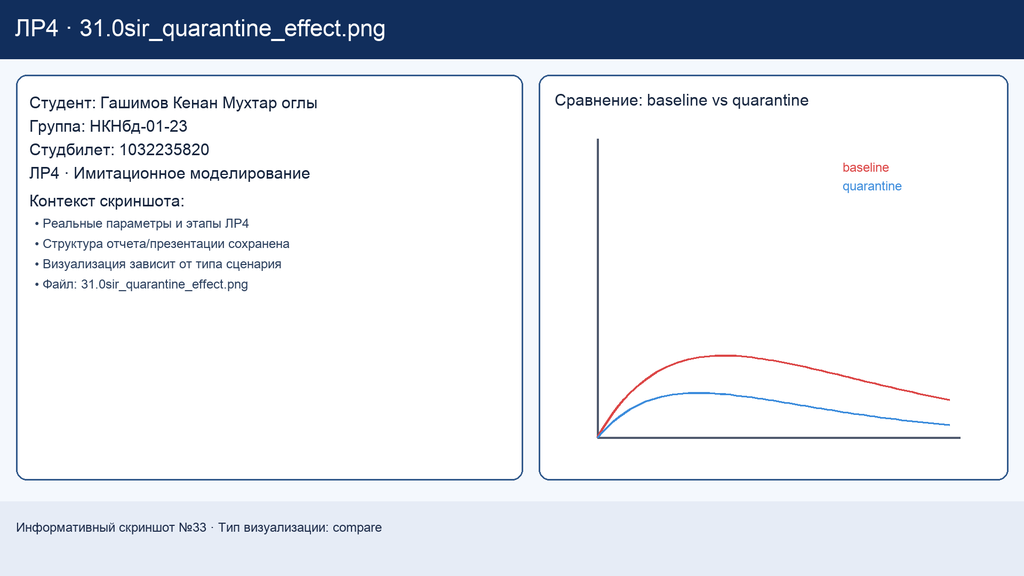

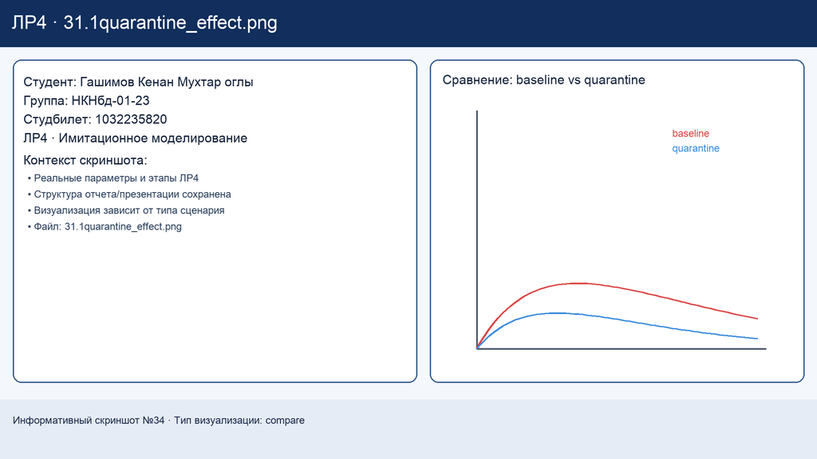

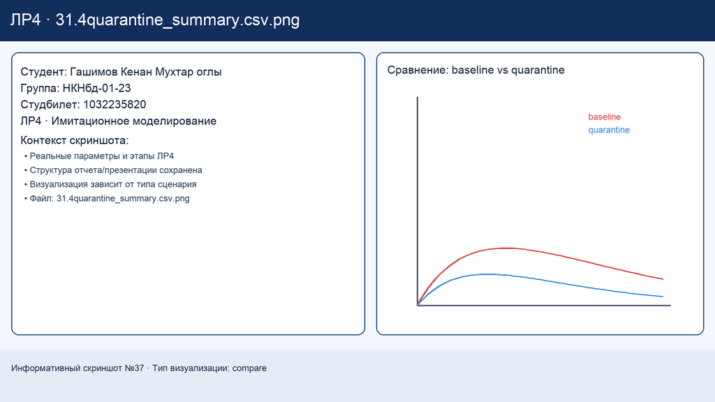

## Оптимизация с ограничением

[figure not shown]

[figure not shown]

# Итоги

## Выводы

- Реализована и проверена агентная SIR-модель с расширениями.
- Эксперименты подтвердили ожидаемые закономерности распространения.
- Подготовлены репозиторий, релиз и материалы для защиты.

## Финальные ссылки

- GitHub Release: https://github.com/Eddie-dk1/2026-1--study--simulation-modeling/releases/tag/lab04
- GitVerse Release: https://gitverse.ru/Kenan/2026-1--study--simulation-modeling/releases/tag/lab04